Research Article

[Psychological and Cognitive Sciences](https://www.pnas.org/topic/psych-soc)

FREE ACCESS

# Hedonism and the choice of everyday activities

August 15, 2016

113 (35) 9769-9773

https://doi.org/10.1073/pnas.1519998113

- Last 12 Months2,872

- Last 12 Months8

## Significance

Decisions we make every day about how to invest our time have crucial personal and societal consequences. Most theories of motivation propose that our daily choices of activities aim to maximize positive affective states but fail to explain when people decide to engage in unpleasant yet necessary activities. We tracked the activities and moods of over 28,000 people in real time and demonstrated that people seek mood-enhancing activities when they feel bad and unpleasant activities when they feel good. These findings clarify how emotions shape behavior and may explain how humans trade off short-term happiness for long-term welfare. Overcoming such trade-offs might be critical for our personal well-being and our survival as a species.

## Abstract

Most theories of motivation have highlighted that human behavior is guided by the hedonic principle, according to which our choices of daily activities aim to minimize negative affect and maximize positive affect. However, it is not clear how to reconcile this idea with the fact that people routinely engage in unpleasant yet necessary activities. To address this issue, we monitored in real time the activities and moods of over 28,000 people across an average of 27 d using a multiplatform smartphone application. We found that people’s choices of activities followed a hedonic flexibility principle. Specifically, people were more likely to engage in mood-increasing activities (e.g., play sports) when they felt bad, and to engage in useful but mood-decreasing activities (e.g., housework) when they felt good. These findings clarify how hedonic considerations shape human behavior. They may explain how humans overcome the allure of short-term gains in happiness to maximize long-term welfare.

[Manage alerts](https://www.pnas.org/action/showPreferences?menuTab=Alerts)

What will you be doing in an hour? Working? Doing your laundry? Having a beer with a friend? Behind this simple question lies one of the most important decisions we face in our lives, namely, how to spend our time. On average, people live about 600,000 h, and whether we decide to spend a greater or lesser number of these hours working, sleeping, socializing, or watching television has crucial consequences for our mental and physical health (1–3).

There are many factors that influence our everyday activities—from financial considerations to social norms to political constraints—yet most theories of motivation have highlighted the crucial role played by negative and positive affective states (4–6). In particular, human behavior is believed to be guided by the hedonic principle, according to which our choices of activities aim to minimize negative affect and maximize positive affect (7).

The hedonic principle has been tested empirically through laboratory studies that have used a wide variety of mood induction techniques (e.g., writing about negative or positive life events, watching sad or happy movies) and then asked individuals to choose among various activities. Results have largely supported the hedonic principle: when they feel bad, most people try to decrease their negative emotions by choosing to engage in activities that make them feel better (e.g., eating comfort food, seeking social support) (8–12); when they feel good, most people try to maintain or even maximize their positive emotions (e.g., playing, engaging in various social, physical, and leisure activities) (13–15)—at least when positive emotions are not considered inappropriate due to social norms or utilitarian concerns (16–18).

Do these laboratory findings generalize to our everyday decisions? Although widely supported in the laboratory, the hedonic principle, without further specification, does not explain much of people’s everyday behavior: if we always try to improve our moods, when are we motivated to do the dishes, wait in line at the post office, or even go to work?

One possibility is that our choice of activities is mostly determined by the demands and constraints of everyday life. In the face of these constraints, the “hedonic opportunism hypothesis” suggests that we try to maximize our mood whenever an opportunity arises. A second possibility is that the hedonic principle applies mainly when people’s affective states are salient (19). According to this “hedonic salience hypothesis,” we are concerned with maximizing our mood when we feel very bad or very good, and we undertake less pleasurable—yet necessary—activities when we are in a more neutral affective state. A third possibility—suggested by Herbert Simon (20) half a century ago—is that people have multiple simultaneous goals, from seeking short-term rewards (e.g., increasing one’s mood state) to pursuing longer-term rewards (e.g., working hard toward a promotion), and affective states help to prioritize among these goals. According to this “hedonic flexibility hypothesis,” whereas negative affect may drive people to seek solace in short-term rewards, positive affect should lead people to shift their priorities toward less pleasant activities that might be important for their longer-term goals (21).

These three hypotheses make different predictions regarding how mood should be related to people’s subsequent choices of activities. The hedonic opportunism hypothesis suggests that mood should not predict the type of activities that people engage in. The hedonic salience hypothesis suggests that extreme mood states should predict a higher propensity to engage in pleasant activities, whereas neutral mood states should predict a higher propensity to engage in useful but unpleasant activities. Finally, the hedonic flexibility hypothesis suggests that negative mood states should predict a higher propensity to engage in pleasant activities, whereas positive mood states should predict a higher propensity to engage in useful but unpleasant activities.

## Results

The results of our analyses are depicted in Fig. 1, and they reveal two key findings. First, people’s daily decisions to engage in one activity rather than another are related to how they currently feel: participants’ mood at time *t* significantly predicted what they would be doing at time for 15 out of 25 activities (posterior probability ; color bars in Fig. 1*A*), a finding that is inconsistent with the hedonic opportunism hypothesis. The effects of mood on people’s choice of activities were stronger for pleasant than unpleasant activities. As depicted in Fig. 1 *C* and *D*, although mood at time *t* significantly predicted people’s propensity to engage in five unpleasant activities at time (i.e., commuting, working, housework, sleeping, and waiting), these activities were more strongly predicted by the day of the week or the time of the day (as measured by the proportion of deviance explained by each degree of freedom of the corresponding variable). In contrast, of the 10 pleasant activities significantly predicted by mood at time *t*, two activities (i.e., eating and childcare) were better predicted by mood than by the day of the week, three activities (i.e., nature, leisure, and culture) were better predicted by mood than by the time of the day, and three activities (i.e., sport, chatting, and drinking) were better predicted by mood than by either day or time. In other words, if you wanted to predict how likely a random stranger whom you meet is to be working, cleaning the dishes, or sleeping a few hours from now, knowing what day or time it is would be more informative than knowing her current mood. If, however, you wanted to predict how likely that person is to exercise, chat with friends, or have a drink in the next few hours, knowing her current mood would give you more information than knowing that it is Saturday or that it is 7:00 PM.

Fig. 1.

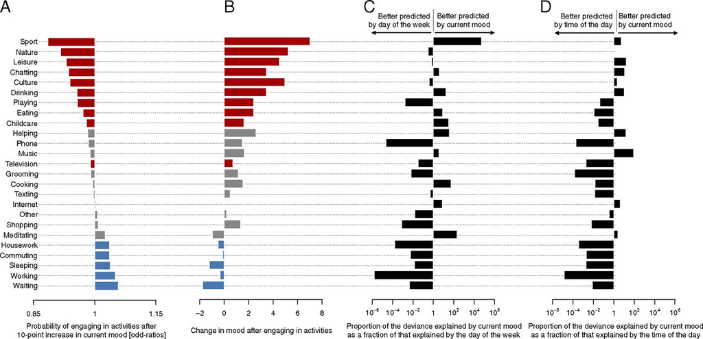

OPEN IN VIEWER

Our findings suggest that mood shapes the decisions people make about which activities to undertake in the next few hours and that, in turn, these activities influence how they feel. However, two alternative explanations of the interplay we observed between activities and mood are possible. The first is that the succession of activities in everyday life might follow a systematic pattern or “rhythm” (e.g., people typically eat breakfast then go to work rather than the other way around). The second is that mood might follow a natural rhythm [e.g., people typically feel in a better mood in the morning than just before lunch (22)].

If activities followed a natural rhythm that was not affected by mood but caused corresponding changes in moods (e.g., eating breakfast makes people happy, working makes people unhappy, and people typically eat breakfast before going to work), then one might expect to observe similar associations between mood and activities as the ones we observed, even if mood actually does not cause any change in people’s choice of activities. In that case, mood at time *t* would not be a valuable predictor of activity at time . To rule out this alternative explanation, we computed, for each activity, the Akaike information criterion (AIC) of a model in which mood at time *t* was removed from the set of independent variables. These analyses revealed that our findings could not be explained by the natural rhythm of activities ().

If mood follows a natural rhythm that is not affected by the activities that people are currently doing but causes corresponding changes in choices of subsequent activities (e.g., people are happier at 8:00 AM than at 11:00 AM, and being happy in the early morning increases the odds they work a few hours later), one might expect to observe similar associations between mood and activities as the ones we observed, even if the choice of activity actually did not cause changes in people’s mood. In that case, the change in mood between times *t* and would solely be predicted by current mood and not by activities at *t* + 1. To rule out this alternative explanation, we compared the AIC of two models predicting the change in mood () from either current mood alone or current mood and activities at time . This analysis revealed that our finding could not be explained by the natural rhythm of mood (). Taken together, these findings offer further support for the hedonic flexibility hypothesis.

## Discussion

Deciding what to do with one’s time is one of the most fundamental choices humans face every day—a choice that has crucial consequences both for individuals and society at large. Our findings demonstrate that people’s everyday decisions regarding which activities to undertake are directly linked to how they feel and follow a remarkably consistent pattern. People seek mood-enhancing activities when they feel bad and engage in unpleasant activities that might promise longer-term payoff when they feel good. Although our data cannot directly tell us whether regularly engaging in unpleasant activities predicts psychological and social adjustment 5 or 10 y down the line, a large body of work has consistently demonstrated the importance of sleeping (23), employment (24), and living in a reasonably clean and organized home (25, 26) on mental and physical health.

The present research shows robust associations between affective states and choices of activity: people’s current mood meaningfully changes (sometimes doubling or tripling) the probability they later engage in certain types of activity, and mood sometimes predicts what people will be doing in the next few hours better than knowing what day or time it is. However, it is important to note that, owing to the study design, our examination of the effect of mood on choice of daily activities was limited to a standard subset of assessed activities. Future research should examine the pervasiveness of the hedonic flexibility principle with a wider range of activities (e.g., via open-ended responses). In addition, further work is needed to examine the underlying mechanism through which affective states relate to choices of activities. For instance, it is possible that indirect effects, such as the impact of mood on people’s concentration or fatigue levels, influence the relationship that we observed. Likewise, the present work has focused on the relationship between mood and people’s choices on average. However, it is very likely that important individual differences exist in the extent to which affective considerations guide people’s daily choices. Investigating the hedonic flexibility principle across various groups of individuals and cultures represents an exciting avenue for future work. Finally, experimental research is needed to establish the causal impact of affective states on daily decisions. One could, for example, manipulate mood by sending positive or negative stimuli on people’s phone and measuring how this impacts their subsequent choices of activity.

Opportunities to indulge in short-term pleasure are all around us—from our favorite hobbies to our favorite ice cream. Our personal well-being and survival potential as a species might crucially depend on our ability to overcome the allure of short-term happiness gains to maximize long-term welfare. The hedonic flexibility principle may explain how humans have and continue to overcome such trade-offs in their everyday life.

## Materials and Methods

### Participants and Experience Sampling.

Participants volunteered for the study by downloading *58 seconds* ([www.58sec.com](http://www.58sec.com/)), a free francophone mobile application for iPhone and Android phones dedicated to measuring various aspects of users’ well-being through short questionnaires presented at random times throughout the day. The project received significant media coverage in France. At initial signup, participants answered several questions about themselves, including age, gender, and country of residence (see Table S1 for detailed information on the composition of the sample). Next, participants were asked which days of the week and within what time windows they wished to receive questionnaire requests (default = 7 d/wk from 9:00 AM to 10:00 PM). Participants could also customize the number of daily questionnaire requests they wanted to receive (default = 4, minimum = 1, maximum = 12). The application algorithm then divided each participant’s day into a number of intervals equal to the number of samples to be requested, and a random time was chosen within each interval. The minimum time between two questionnaires was set to 1 h to avoid large artifactual autocorrelations between answers to the same question in consecutive tests. The random sampling was ensured through a notification system that did not require users to be connected to the Internet. New random times were generated each day, and the times were independently randomized for each participant. At each of these times, participants received a notification on their mobile phone informing them that a new questionnaire was available (Fig. S1*A*). They then had the possibility to take the questionnaire, snooze it (i.e., delay it by 9 min), or reject it (Fig. S1*B*). The two questions asked to participants were “How do you currently feel?” (Fig. S1*C*) and “What are you currently doing?” and were always presented in that order (i.e., mood then activity). The frequency of recorded results as a function of time and day is reported in Fig. S2. In the present paper, we refer to activities that are associated with positive changes in mood (compared with the previous mood level) as pleasant activities and activities that are associated with negative changes in mood as unpleasant activities.

Table S1.

Characteristics of the sample (*n* = 28,212)

[output not shown]

Expand for more

OPEN IN VIEWER

Fig. S1.

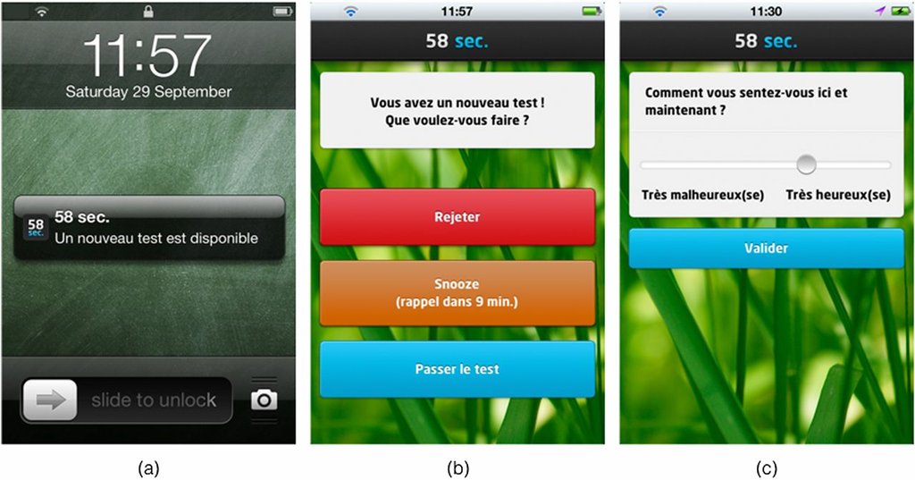

(*A*) Participants were presented with a notification (and its associated auditory or vibratory cue) informing them that a new test was available. (*B*) By clicking on the notification, they were then prompted to either reject the test (“Rejeter”), snooze it and receive a reminder 9 min later (“Snooze”), or take the test (“Passer le test”). (*C*) The test then consisted of several questions (one per screen).

OPEN IN VIEWER

Fig. S2.

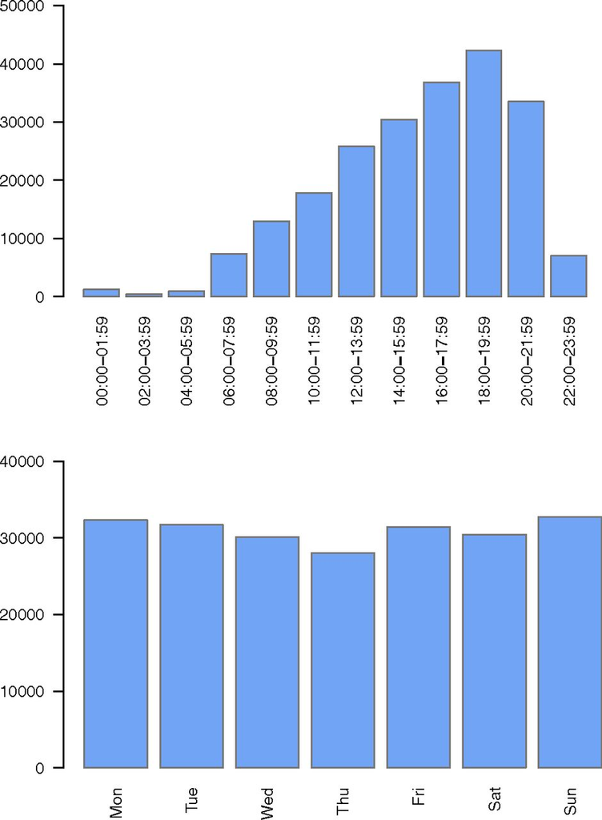

Frequency of results recorded as a function of the time of day and day of week.

OPEN IN VIEWER

This study has been approved in written form as part of a broader project on emotions in everyday life by The Ethics Committee of the University of Groningen, The Netherlands. The study method was carried out in accordance with the approved guidelines. All study protocols were approved by the aforementioned committee. At initial sign-up, participants provided their written informed consent.

### Regression Model.

[1]

[2]

[3]

[4]

[5]

[6]

Model **1** is the null baseline model that has no predictor. Model **2** assumes that current mood has no effect on the decision to later engage in an activity. Model **3** assumes that no covariates are required to express the relation between mood and the decision to engage in activities. Models **4** and **5** include all covariates described above. Model **5** includes additional interaction terms to express the influence of the actual time elapsed between two reports (). This model is based on the assumption that, if current mood has an effect on the decision to later engage in an activity, then this effect must be stronger if the actual time difference between two measurements, , is smaller. The same applies to the latency effect. Finally, model **6** includes the dichotomous variables of all of the previous activities at time *t* and not just the *j*th activity.

The resulting AIC (computed using the aic function from R, version 3.1.0) for all activities and all models are summarized in Table S2. For readability purposes, we normalized each AIC by the maximum AIC among all models. This does not alter our conclusions because we are only interested in the identity of the model that leads to the smallest AIC. Model **6** is the most appropriate model for all 25 activities. Consequently, we used model **6** throughout our analyses.

Table S2.

Normalized AIC for all models and all activities

| Activity (label on Fig. 1) | Model 1 | Model 2 | Model 3 | Model 4 | Model 5 | Model 6 |
| --- | --- | --- | --- | --- | --- | --- |
| Working, studying (working) | 1.0000 | 0.8229 | 0.9987 | 0.8222 | 0.8137 | **0.8026** |
| Commuting (commuting) | 1.0000 | 0.9501 | 0.9995 | 0.9497 | 0.9451 | **0.9362** |
| Cooking (cooking) | 1.0000 | 0.9554 | 0.9983 | 0.9554 | 0.9525 | **0.9455** |
| Housework (housework) | 1.0000 | 0.9713 | 0.9996 | 0.9709 | 0.9671 | **0.9574** |
| Shopping (shopping) | 1.0000 | 0.9315 | 0.9988 | 0.9316 | 0.9261 | **0.9207** |
| Waiting, being in line (waiting) | 1.0000 | 0.9563 | 0.9976 | 0.9553 | 0.9522 | **0.9419** |
| Taking care of children (childcare) | 1.0000 | 0.8760 | 0.9980 | 0.8758 | 0.8722 | **0.8668** |
| Playing (playing) | 1.0000 | 0.9563 | 0.9977 | 0.9558 | 0.9545 | **0.9498** |
| Helping someone (helping) | 1.0000 | 0.9620 | 0.9947 | 0.9619 | 0.9592 | **0.9494** |
| Sleeping, resting (resting) | 1.0000 | 0.9296 | 0.9975 | 0.9291 | 0.9199 | **0.9067** |
| Meditating, praying (meditating) | 1.0000 | 0.9643 | 0.9988 | 0.9642 | 0.9642 | **0.9573** |
| Showering, getting ready (grooming) | 1.0000 | 0.9758 | 0.9998 | 0.9758 | 0.9709 | **0.9618** |
| Chatting (chatting) | 1.0000 | 0.9414 | 0.9848 | 0.9395 | 0.9363 | **0.9267** |
| Eating (eating) | 1.0000 | 0.9563 | 0.9961 | 0.9560 | 0.9518 | **0.9448** |
| Drinking (drinking) | 1.0000 | 0.9604 | 0.9871 | 0.9599 | 0.9576 | **0.9394** |
| Texting, emailing, social networking (texting) | 1.0000 | 0.9345 | 0.9999 | 0.9345 | 0.9321 | **0.9173** |
| Calling someone (phone) | 1.0000 | 0.9774 | 0.9999 | 0.9774 | 0.9744 | **0.9643** |
| Being on the Internet (Internet) | 1.0000 | 0.9632 | 0.9987 | 0.9632 | 0.9597 | **0.9506** |
| Watching TV (TV) | 1.0000 | 0.8879 | 0.9992 | 0.8879 | 0.8813 | **0.8742** |
| Listening to music (music) | 1.0000 | 0.9592 | 0.9969 | 0.9592 | 0.9550 | **0.9438** |
| Cultural activity (culture) | 1.0000 | 0.9246 | 0.9855 | 0.9238 | 0.9191 | **0.9125** |
| Doing sport (sport) | 1.0000 | 0.9616 | 0.9774 | 0.9560 | 0.9470 | **0.9417** |
| Going out into nature (nature) | 1.0000 | 0.8728 | 0.9732 | 0.8710 | 0.8653 | **0.8560** |
| Leisure (leisure) | 1.0000 | 0.9245 | 0.9803 | 0.9231 | 0.9208 | **0.9143** |
| Other | 1.0000 | 0.9732 | 0.9998 | 0.9732 | 0.9711 | **0.9662** |

Expand for more

Bold numbers identify the best model for each activity.

OPEN IN VIEWER

### Statistical Analyses.

To assess whether people’s current mood significantly predicts their future decision to engage in an activity, we computed the probability that the coefficient in model **6** is larger than 0 for all 25 activities. If that probability is very large (i.e., close to 1), then an increase in current mood is almost certainly associated with an increase in the odds to engage in the *j*th activity. Conversely, if this probability is very small (i.e., close to zero), then a decrease in current mood almost certainly leads to an increase in the odds to engage in the *j*th activity. If the current mood does not reliably predict the odds to engage in the *j*th activity, then this probability ought to be around 0.5, reflecting our ignorance of changes in future odds beyond chance level (). This posterior probability is estimated in a Bayesian approach and can be interpreted as the Bayesian equivalent of conventional *P* values, which assess whether the coefficients are significantly different from zero. Specifically, we estimated the parameters of model **6** using the inference method implemented as the bayesglm function from the arm package (28) (version 1.7-05) in R (version 3.1.0), using the default parameters. This function returns estimates for the posterior mean (*μ*) and SE (*σ*) of . Assuming that the posterior distribution of can be approximated by a Gaussian distribution, we computed the probability that as follows:

We analyzed the proportion of explained deviance (equivalent to the proportion of variance for generalized linear models) using the function anova in R. We compared the proportion of deviance explained by the mood at time *t* to that explained by the day of the week and the time of the day. Because the day of the week adds 2 degrees of freedom to the model and is therefore more likely to explain more deviance due to chance alone, we report it as the proportion of explained deviance per degree of freedom by dividing its explained deviance by 2, and similarly for the time of day, which has 11 degrees of freedom.

### Interpretation of ORs.

and those ORs for doing housework as follows:

These ORs can be transformed back to the probability of engaging in these activities by using the inverse formula for ORs: .

### Robustness Analyses.

To test the robustness of our results, we randomly split the dataset in 10 subsets, each containing the data from 2,822 subjects except for the 10th subset containing the data from 2,814 subjects. We estimated the parameters of model **6** in each of these subsets independently. Results were found to be virtually identical across the 10 samples.

### Ruling Out Explanations by Natural Rhythms.

To rule out the alternative explanation that the rhythm of activities in everyday life might account for our findings, we computed, for each activity, the AIC of the following model **7** (which is similar to our original model **6** except that mood at time *t* was removed from the set of independent variables):

[7]

Table S3.

Normalized AIC of model 6 and normalized AIC of the model corresponding to the natural rhythm) for all activities

[output not shown]

Expand for more

Bold numbers identify the best model for each activity.

OPEN IN VIEWER

To rule out the alternative explanation that the rhythm of mood in everyday life might account for our findings, we computed the AIC for the following two models:

[8]

[9]

This analysis revealed that the AIC of model **9** was lower than that of model **8** by over 4,000 points, which rejects the null hypothesis that model **8** is as good or better than model **9** in terms of information loss (). These results cast doubts on the hypothesis that natural rhythm of mood could explain our pattern of results.

## Supporting Information

Supporting Information (PDF)

Supporting Information

- [Download](https://www.pnas.org/doi/suppl/10.1073/pnas.1519998113/suppl_file/pnas.201519998SI.pdf)
- 260.13 KB

## Note

This article is a PNAS Direct Submission.

## References

1

D Kahneman, AB Krueger, DA Schkade, N Schwarz, AA Stone, A survey method for characterizing daily life experience: The day reconstruction method. *Science* **306**, 1776–1780 (2004).

[Crossref](https://doi.org/10.1126/science.1103572)

[PubMed](https://www.ncbi.nlm.nih.gov/pubmed/15576620)

Google Scholar

2

LC Hawkley, MH Burleson, GG Berntson, JT Cacioppo, Loneliness in everyday life: Cardiovascular activity, psychosocial context, and health behaviors. *J Pers Soc Psychol* **85**, 105–120 (2003).

[Crossref](https://doi.org/10.1037/0022-3514.85.1.105)

[PubMed](https://www.ncbi.nlm.nih.gov/pubmed/12872887)

Google Scholar

3

MA Killingsworth, DT Gilbert, A wandering mind is an unhappy mind. *Science* **330**, 932 (2010).

Go to reference

[Crossref](https://doi.org/10.1126/science.1192439)

[PubMed](https://www.ncbi.nlm.nih.gov/pubmed/21071660)

[Google Scholar](https://scholar.google.com/scholar_lookup?title=A+wandering+mind+is+an+unhappy+mind&author=MA+Killingsworth&author=DT+Gilbert&publication_year=2010&pages=932&doi=10.1126%2Fscience.1192439&pmid=21071660)

4

ET Higgins, Beyond pleasure and pain. *Am Psychol* **52**, 1280–1300 (1997).

Go to reference

[Crossref](https://doi.org/10.1037/0003-066X.52.12.1280)

[PubMed](https://www.ncbi.nlm.nih.gov/pubmed/9414606)

[Google Scholar](https://scholar.google.com/scholar_lookup?title=Beyond+pleasure+and+pain&author=ET+Higgins&publication_year=1997&pages=1280-1300&doi=10.1037%2F0003-066X.52.12.1280&pmid=9414606)

5

S Freud *Beyond the Pleasure Principle* (Hogarth, Standard Ed, London, 1920).

[Google Scholar](https://scholar.google.com/scholar_lookup?title=Beyond+the+Pleasure+Principle&author=S+Freud&publication_year=1920)

6

J Bentham *An Introduction to the Principles of Morals and Legislation* (Clarendon, Oxford, 1879).

Go to reference

[Google Scholar](https://scholar.google.com/scholar_lookup?title=An+Introduction+to+the+Principles+of+Morals+and+Legislation&author=J+Bentham&publication_year=1879)

7

DL Schacter, DT Gilbert, DM Wegner *Psychology* (Worth Publishers, 2nd Ed, New York, 2011).

Go to reference

[Google Scholar](https://scholar.google.com/scholar_lookup?title=Psychology&author=DL+Schacter&author=DT+Gilbert&author=DM+Wegner&publication_year=2011)

8

WN Morris, NP Reilly, Toward the self-regulation of mood: Theory and research. *Motiv Emot* **11**, 215–249 (1987).

Go to reference

[Crossref](https://doi.org/10.1007/BF01001412)

[Google Scholar](https://scholar.google.com/scholar_lookup?title=Toward+the+self-regulation+of+mood%3A+Theory+and+research&author=WN+Morris&author=NP+Reilly&publication_year=1987&pages=215-249&doi=10.1007%2FBF01001412)

9

B Parkinson, P Totterdell, Classifying affect-regulation strategies. *Cogn Emotion* **13**, 277–303 (1999).

[Crossref](https://doi.org/10.1080/026999399379285)

[Google Scholar](https://scholar.google.com/scholar_lookup?title=Classifying+affect-regulation+strategies&author=B+Parkinson&author=P+Totterdell&publication_year=1999&pages=277-303&doi=10.1080%2F026999399379285)

10

R Saavedra, PC Earley, Choice of task and goal under conditions of general and specific affective inducement. *Motiv Emot* **15**, 45–65 (1991).

[Crossref](https://doi.org/10.1007/BF00991475)

Google Scholar

11

RE Thayer, JR Newman, TM McClain, Self-regulation of mood: Strategies for changing a bad mood, raising energy, and reducing tension. *J Pers Soc Psychol* **67**, 910–925 (1994).

[Crossref](https://doi.org/10.1037/0022-3514.67.5.910)

[PubMed](https://www.ncbi.nlm.nih.gov/pubmed/7983582)

Google Scholar

12

DM Tice, E Bratslavsky, RF Baumeister, Emotional distress regulation takes precedence over impulse control: If you feel bad, do it! *J Pers Soc Psychol* **80**, 53–67 (2001).

Go to reference

[Crossref](https://doi.org/10.1037/0022-3514.80.1.53)

[PubMed](https://www.ncbi.nlm.nih.gov/pubmed/11195891)

Google Scholar

13

D Forest, MS Clark, J Mills, AM Isen, Helping as a function of feeling state and nature of the helping behavior. *Motiv Emot* **3**, 161–169 (1979).

Go to reference

[Crossref](https://doi.org/10.1007/BF01650601)

Google Scholar

14

AM Isen, SF Simmonds, The effect of feeling good on a helping task that is incompatible with good mood. *Soc Psychol* **41**, 346–349 (1978).

[Crossref](https://doi.org/10.2307/3033588)

Google Scholar

15

DT Wegener, RE Petty, Mood management across affective states: The hedonic contingency hypothesis. *J Pers Soc Psychol* **66**, 1034–1048 (1994).

Go to reference

[Crossref](https://doi.org/10.1037/0022-3514.66.6.1034)

[PubMed](https://www.ncbi.nlm.nih.gov/pubmed/8046576)

Google Scholar

16

R Erber, DM Wegner, N Therriault, On being cool and collected: Mood regulation in anticipation of social interaction. *J Pers Soc Psychol* **70**, 757–766 (1996).

Go to reference

[Crossref](https://doi.org/10.1037/0022-3514.70.4.757)

[PubMed](https://www.ncbi.nlm.nih.gov/pubmed/8636896)

Google Scholar

17

WG Parrott, Beyond hedonism: Motives for inhibiting good moods and for maintaining bad moods. *Handbook of Mental Control* (Prentice-Hall, Englewood Cliffs, NJ), pp. 278–305 (1993).

[Google Scholar](https://scholar.google.com/scholar_lookup?title=Beyond+hedonism%3A+Motives+for+inhibiting+good+moods+and+for+maintaining+bad+moods&author=WG+Parrott&publication_year=1993&pages=278-305)

18

M Tamir, What do people want to feel and why? Pleasure and utility in emotion regulation. *Curr Dir Psychol Sci* **18**, 101–105 (2009).

Go to reference

[Crossref](https://doi.org/10.1111/j.1467-8721.2009.01617.x)

Google Scholar

19

GH Gendolla, On the impact of mood on behavior: An integrative theory and a review. *Rev Gen Psychol* **4**, 378–408 (2000).

Go to reference

[Crossref](https://doi.org/10.1037/1089-2680.4.4.378)

[Google Scholar](https://scholar.google.com/scholar_lookup?title=On+the+impact+of+mood+on+behavior%3A+An+integrative+theory+and+a+review&author=GH+Gendolla&publication_year=2000&pages=378-408&doi=10.1037%2F1089-2680.4.4.378)

20

HA Simon, Motivational and emotional controls of cognition. *Psychol Rev* **74**, 29–39 (1967).

Go to reference

[Crossref](https://doi.org/10.1037/h0024127)

[PubMed](https://www.ncbi.nlm.nih.gov/pubmed/5341441)

[Google Scholar](https://scholar.google.com/scholar_lookup?title=Motivational+and+emotional+controls+of+cognition&author=HA+Simon&publication_year=1967&pages=29-39&doi=10.1037%2Fh0024127&pmid=5341441)

21

CS Carver, MF Scheier, Goals and emotion. *Handbook of Cognition and Emotion* (Guilford, New York), pp. 176–194 (2013).

Go to reference

[Google Scholar](https://scholar.google.com/scholar_lookup?title=Goals+and+emotion&author=CS+Carver&author=MF+Scheier&publication_year=2013&pages=176-194)

22

SA Golder, MW Macy, Diurnal and seasonal mood vary with work, sleep, and daylength across diverse cultures. *Science* **333**, 1878–1881 (2011).

Go to reference

[Crossref](https://doi.org/10.1126/science.1202775)

[PubMed](https://www.ncbi.nlm.nih.gov/pubmed/21960633)

Google Scholar

23

FP Cappuccio, D Cooper, L D’Elia, P Strazzullo, MA Miller, Sleep duration predicts cardiovascular outcomes: A systematic review and meta-analysis of prospective studies. *Eur Heart J* **32**, 1484–1492 (2011).

Go to reference

[Crossref](https://doi.org/10.1093/eurheartj/ehr007)

[PubMed](https://www.ncbi.nlm.nih.gov/pubmed/21300732)

Google Scholar

24

F McKee-Ryan, Z Song, CR Wanberg, AJ Kinicki, Psychological and physical well-being during unemployment: A meta-analytic study. *J Appl Psychol* **90**, 53–76 (2005).

Go to reference

[Crossref](https://doi.org/10.1037/0021-9010.90.1.53)

[PubMed](https://www.ncbi.nlm.nih.gov/pubmed/15641890)

Google Scholar

25

LT Graham, SD Gosling, CK Travis, The psychology of home environments: A call for research on residential space. *Perspect Psychol Sci* **10**, 346–356 (2015).

Go to reference

[Crossref](https://doi.org/10.1177/1745691615576761)

[PubMed](https://www.ncbi.nlm.nih.gov/pubmed/25987512)

Google Scholar

26

DE Saxbe, R Repetti, No place like home: Home tours correlate with daily patterns of mood and cortisol. *Pers Soc Psychol Bull* **36**, 71–81 (2010).

Go to reference

[Crossref](https://doi.org/10.1177/0146167209352864)

[PubMed](https://www.ncbi.nlm.nih.gov/pubmed/19934011)

Google Scholar

27

H Akaike, A new look at the statistical model identification. *IEEE Trans Automat Contr* **19**, 716–723 (1974).

Go to reference

[Crossref](https://doi.org/10.1109/TAC.1974.1100705)

[Google Scholar](https://scholar.google.com/scholar_lookup?title=A+new+look+at+the+statistical+model+identification&author=H+Akaike&publication_year=1974&pages=716-723&doi=10.1109%2FTAC.1974.1100705)

28

A Gelman, A Jakulin, MG Pittau, YS Su, A weakly informative default prior distribution for logistic and other regression models. *Ann Appl Stat* **2**, 1360–1383 (2008).

Go to reference

[Crossref](https://doi.org/10.1214/08-AOAS191)

Google Scholar

SHOW ALL REFERENCES SHOW LESS

- [Research Article](https://www.pnas.org/topic/type/research-article)August 15, 2016Free Access

### [Large conditional single-photon cross-phase modulation](https://www.pnas.org/doi/10.1073/pnas.1524117113)

**Most Read**

- [Research Article](https://www.pnas.org/topic/type/research-article)December 30, 2013Open Access

### [Neural network retuning and neural predictors of learning success associated with cello training](https://www.pnas.org/doi/full/10.1073/pnas.1721414115)

**Most Cited**

[Research Article](https://www.pnas.org/topic/type/research-article)November 12, 2019Free Access

### [Veil-of-ignorance reasoning favors the greater good](https://www.pnas.org/doi/full/10.1073/pnas.1910125116)

[Research Article](https://www.pnas.org/topic/type/research-article)March 2, 2015Free Access

### [Perceived intent motivates people to magnify observed harms](https://www.pnas.org/doi/full/10.1073/pnas.1501592112)

[Research Article](https://www.pnas.org/topic/type/research-article)January 8, 2018Free Access

### [Preferences for moral vs. immoral traits in others are conditional](https://www.pnas.org/doi/full/10.1073/pnas.1714945115)

Get in-depth science stories sent to your inbox twice a month.

[CONTINUE](https://www.pnas.org/help/cookie-policy)

Reference #1